# Chicago_Crime_Report_2016_2022

Mikhail Revenko

2022-03-11

# Introduction

This is a case study of Chicago’s Crime statistics for the years 2016-2022. We will use the official Chicago Police Department database which can be accessed through Google’s BigQuery platform.

The goals of the project are:

- Establish a Tableau dashboard to monitor crime statistics such as arrest rates and crime density.
- Establish a Tableau dashboard to monitor police department (beat) arrest rates individually.
- Check for correlation of crime rate and Chicago PD yearly budget.
- Look for any interesting patterns
- Learn about data analysis tools

# Data Selection/Cleaning

Prior to any cleaning it is always advised to check the metadata of the data set for additional information about what the columns mean as well as where the data set comes from. This will allow you to get integral background knowledge about the data.

In this situation we have access to an trusted data source. I verified the integrity of the data in SQL. Suggested things to check for are:

- Null values
- Out of range quantities or dates.
- Spelling mistakes
- Incorrect data-types
- Completeness

To verify the integrity I utilized several SQL queries to check for all of the values mentioned above. Ill include some sample queries here.

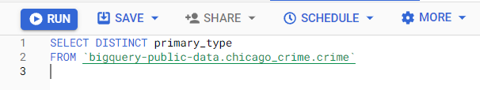

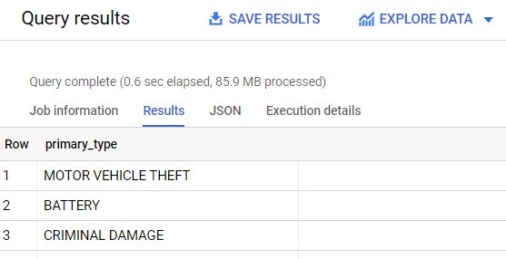

This allows us to visually inspect the distinct kinds of crime that exist. We notice at the end of the query that we have three “Non-Criminal” activities that we now know we can filter out in the future since we only want to look at criminal activity.

Using SQL we can also check for all the other errors listed above.

Now that we have inspected and cleaned the data we can proceed to running the main query. NOTE: I am aware that the transformations and filtering done to the data later in the report can easily be done in SQL, I am doing the transformations in R to better learn the programming language.

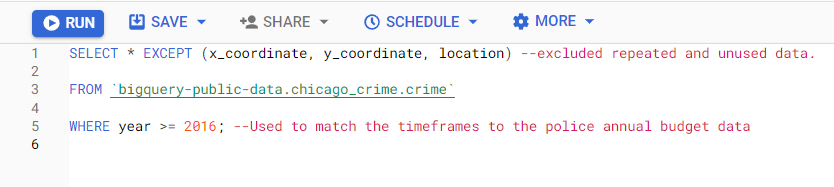

Main Query

This query generates the data set that we will be using for the bulk of the project. It excludes some repeated data as well as some data that wont be used in order to reduce the size of the data set. SELECT star selects all of the data and the except statement excludes whatever is inside the brackets. We are also only using the data from the year 2016 and forward because the Chicago police funding data I have only goes back to 2016.

# Generating a Tableau Dashboard

[Chicago Crime Dashboard](https://public.tableau.com/app/profile/mikhail.revenko/viz/Chicago_Crime_Dashboard_2016_2022/Dashboard1)

I wanted to make several filterable visuals that the Chicago police dept. can use to better see the crime statistics in their jurisdiction. Firstly I made a map where we could select the crime type and the year and visually see the locations on a map where said crimes were taking place and whether or not an arrest has been made. I also found a [map](https://news.wttw.com/sites/default/files/Map%20of%20Chicago%20Police%20Districts%20and%20Beats.pdf) of the police beats and their locations in Chicago. It is useful to refer to when using the map visualization in tableau.

The next graphic I made was a stacked bar chart showing how much of a particular crime happens, during what time of the year, and on which police “beats” territory it happens on. Additionally the arrest rates can clearly be seen on the graph. Interestingly enough we can notice on this visualization that crime generally peaks around the summer months; June, July & August.

I also made a table of bar charts that shows the arrest rates for each crime. This table did not make it into the final dashboard but it gave some very important insights. The main one being that arrest rate is not a good metric for every type of crime in this data set. For instance narcotics have arrest rates of nearly 100% because a majority of the crime is possession of drugs. Meaning they get caught with it and therefor arrested. In this case we would need to estimate the amount of narcotics related crimes and then compare it to the arrested amount. Whereas a robbery is a crime that happens and then is investigated, after which the culprit may or may not be caught. In this case arrest rate is a good indication of police performance.

The other thing I learned from creating this table is customized calculations. I’m going to share my table and calculation here:

(COUNT( IF ([Arrest] = TRUE) THEN ([Arrest]) END) / COUNT([Primary Type])) * 100 This calculation counts the arrests and then divides it by the total number of crimes to get a % arrested statistic.

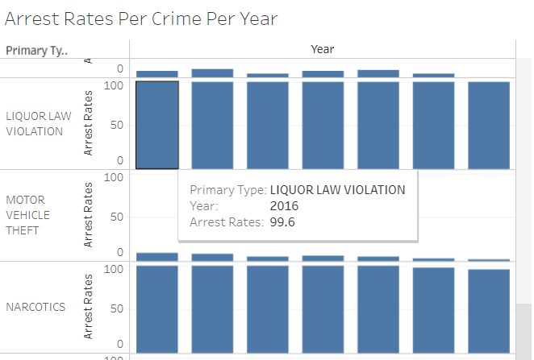

Arrest Rate Table

# Using R to check for Correlation

First we would load the CSV file that we downloaded from Big Query and ask R to read it. Then we could use functions like head() to view the first six rows and glimpse() to get more information about the data. It is worthwhile to mention that the “tidyverse” and “plyr” libraries should be installed and loaded to provide the necessary functions for our analysis.

```r
#load tidyverse library
library(tidyverse)
library(patchwork) # To display 2 charts together
library(plyr)

#read data from SQL query
Chicago_Crime <- read.csv("Chicago_Crime_2016_2022.csv")

#read data from Chicago police dept budget file
CPD_budget <- read.csv("CPD_budget_2016_2021.csv",fileEncoding="UTF-8-BOM")
```

Now that we have our data loaded into R we can proceed to transform it into data that can more easily be plotted and visualized. First, all of the non-criminal entries need to be removed since we are focused on crime rates. Second, we need to get a summary of all crime in the form of two tables. The first will have total amount of criminal incidents broken down by year. The second table will have all criminal incidents where arrests have been made also broken down by year.

```r
arrest_numbers <- Chicago_Crime %>%
  #filter out non criminal activity
  filter(primary_type != "NON-CRIMINAL" & primary_type != "NON - CRIMINAL" & primary_type != "NON-CRIMINAL (SUBJECT SPECIFIED)") %>%
  #Keep crimes where arrests have been made
  filter(arrest == "true")%>%
  #make a table of arrests per year
  ddply(.(year), nrow)
  #change name of new column to n_arrests
names(arrest_numbers)[names(arrest_numbers) == 'V1'] <- "n_arrests"
```

NOTE: the crime_numbers table is generated the same way, only the “filter(arrest ==”true”)” is removed since we are looking to get a breakdown of all crime.

Now we can merge all of the tables together as well as adding a column of the calculated yearly arrest rate to prepare the data table for plotting and further calculations.

```r
#inner join the tables of crime numbers and arrest numbers
chicago_arrest_statistics <- merge(x=crime_numbers,y=arrest_numbers,by="year")%>%
  #add a column for arrest rates in %
  mutate(arrest_rate = (n_arrests/n_crimes)*100)
```

Here we can see a summary of the data table that has been created. The primary key: year, as well as the number of crimes, number of arrests, the arrest rate (given in percent) and the Chicago Police Department budget in $ (USD).

Find the Chicago Police Dept. budget was found here: [CPD Budget](https://igchicago.org/wp-content/uploads/2021/09/Understanding-the-Chicago-Police-Departments-Budget.pdf)

Keep in mind that you need a VPN with a USA based server location to be able to access the data.

```r
chicago_arrests_vs_funding <- merge(chicago_arrest_statistics,CPD_budget,by="year")
head(chicago_arrests_vs_funding)
```

```
##   year n_crimes n_arrests arrest_rate CPD_budget
## 1 2016   269620     52995    19.65544 1452499521
## 2 2017   268877     52603    19.56396 1494128777
## 3 2018   268516     53821    20.04387 1575588780
## 4 2019   260952     56129    21.50932 1656002057
## 5 2020   211597     33968    16.05316 1762078349
## 6 2021   206155     24823    12.04094 1698735503
```

Upon plotting the data for crime and funding we can see that as the funding increases the number of crimes tend to decrease. A good way to verify this inverse correlation is to calculate the correlation coefficient. The correlation coefficient can vary from -1 to 1. A negative coefficient indicates an inverse relationship. Strong correlation is shown by a correlation coefficient of less than -0.8 (for inverse relationship) or greater than 0.8 (for a direct relationship).

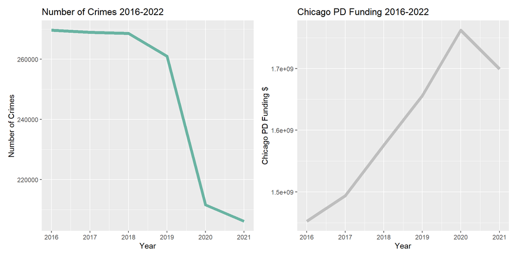

Now, lets calculate the correlation coefficient for number of crimes and CPD funding. In theory as we fund and therefor have a more equipped police force, there should be less crimes. Given this, the correlation coefficient should be less than -0.8.

```r
#correlation between number of crimes and CPD Budget
correlation_funding_crime <- cor(chicago_arrests_vs_funding$n_crimes, chicago_arrests_vs_funding$CPD_budget)
#display result
correlation_funding_crime
```

```
## [1] -0.8350693
```

The result is a -0.835 correlation coefficient. This indicates that there is a strong, inverse correlation between crime rate and Chicago police budget. As the funding increases the crime numbers decrease. Keep in mind that just because these numbers are correlated, it does not prove that increased funding caused the crime rate to drop.

```r
#correlation between arrest rate and CPD Budget
correlation_funding_arrests <- cor(chicago_arrests_vs_funding$arrest_rate , chicago_arrests_vs_funding$CPD_budget)
#display result
correlation_funding_arrests
```

```
## [1] -0.5584397
```

# A Deeper Dive into the Data

To find out what may cause our correlation calculation to show an unexpected result, lets make use of the tableau visualization to help spot any inconsistencies. We know from prior analysis, that there are several crimes for which the arrest rate is nearly 100%, such as drug possession. These type of crimes would skew the arrest rate as there doesn’t really need to be any investigation to catch the culprit after, unlike a burglary. So if these crimes were rapidly rising or falling, it would skew the arrest rate. Lets filter for all of these crimes and see their historical trends.

[Chicago Crime Dashboard](https://public.tableau.com/app/profile/mikhail.revenko/viz/Chicago_Crime_Dashboard_2016_2022/Dashboard1)

- CONCEALED CARRY LICENSE VIOLATION
- GAMBLING
- INTERFERENCE WITH PUBLIC OFFICER
- LIQUOR LAW VIOLATION
- NARCOTICS
- OTHER NARCOTIC VIOLATION

The resulting chart shows:

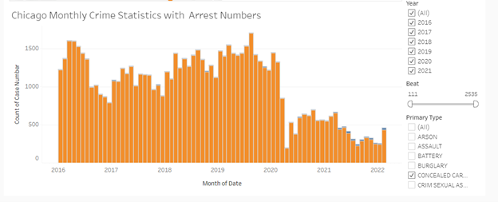

Tableau Results

```r
#correlation between arrest rate and CPD Budget adjusted for bias
cor(chicago_arrests_vs_funding_no_bias$arrest_rate_unbiased, chicago_arrests_vs_funding_no_bias$CPD_budget)
```

```
## [1] -0.6095641
```

We arrive at a correlation coefficient of -0.609. This indicates weak correlation between police budget and arrest rates, but, its negative. It seems as though increased funding is weakly correlated to lower arrest rates. This doesn’t exactly make sense in the context of the expectations. Why would arrest rates not improve as officers become more equipped? Unfortunately, the dataset does not hold the answers. At this point it is advised to ask for more data or consult with subject matter experts such as police chiefs, HR, and Sargents to find some other potential reasons that arrest rates are not improving.